[figure not shown]

# Unidades de Conservação e Desmatamento

# Introdução

Unir dados das **Unidades de Conservação** disponibilizados pelo **Ministério de Meio Ambiente e Mudanças Climáticias** com os de **Incremento de Desmatamento por bioma e município** do **Instituto Nacional de Pesquisa Espacial**. Com o objetivo de facilitar a análises como a efetividade das ações de conservação no incremento de desmatamento.

### Observações Iniciais

- Considera se como desmatamento a supressão da vegetação nativa, independentemente da futura utilização destas áreas.
- Os dados referentes ao Incremento de desmatamento por bioma e municipio foram obtidos da plataforma TerraBrasilis(INPE), a partir de uma painel interativo de incremento anual de desmatamento por bioma, embora os dados originais de incremento na supressão da vegetação nativa tenham sido obtidos através da interpretação de imagens de satélites, para todos os biomas.
- Em 2019 o IBGE lança o Mapa de Biomas e Sistema Costeiro-Marinho do Brasil, na escala 1:250.000, com um detalhamento 20 vezes maior que o da edição anterior, publicada em 2004.

# Diagrama Dados

**Diagrama UML dos Dados de Incremento de Desmatamneto**

[figure not shown]

**Diagrama UML dos Dados de Unidades de Conservação**Na organização original desse conjunto de dados todos os atributos aparentam estar em uma mesma tabela, o que pode gerar anomalias de inserção e atualização. O diagrama abaixo foi adaptado em relaçao ao original para melhor garantir consistencia dos dadso.

[figure not shown]

**Diagrama Intersecção Conjunto de Dados**

[figure not shown]

# Análise de Dados

# Dados de Incremento de Desmatamento por Bioma

Os dados de desmatamento são registrados por bioma, a fim de facilitar a análise reunirei os dados em uma unica tabela mantendo a na 3NF.

A ausência de elementos nulo na tabela de incremento de desmatentos dos biomas, sugere consistência na completude dos dados. Entretanto, o intervalo temporal da cobertura dos biomas não é homogênea, o que compromete parcialmente a completudo da tabela como um todo.

#### Análise Exploratória

Devido a diversas distinções entre os biomas brasileiros, como área territorial e dinâmica do uso do solo, os dados serão analisados por bioma, Para garantir coerência nas estatíticas.

#### Inconsistência

Para a construção da análise exploratória, os dados de incremento anual de desmatamento foram inicialmente organizados no nível municipal. Em seguida, foi realizada a agregação por estado, somando-se as áreas desmatadas dos municípios correspondentes. Por fim, a área total desmatada foi agrupada por bioma, permitindo observar a evolução anual do desmatamento em diferentes regiões ecológicas do país.

|  | year | areakm_acumulado | bioma |
| --- | --- | --- | --- |
| 0 | 2008 | 124.407977 | Amazônia |
| 1 | 2009 | 183.353863 | Amazônia |
| 2 | 2010 | 241.803349 | Amazônia |
| 3 | 2011 | 295.816885 | Amazônia |
| 4 | 2012 | 337.088491 | Amazônia |
| ... | ... | ... | ... |
| 123 | 2019 | 297.678672 | Pampa |
| 124 | 2020 | 306.563857 | Pampa |
| 125 | 2021 | 321.827431 | Pampa |
| 126 | 2022 | 329.377746 | Pampa |
| 127 | 2023 | 335.923452 | Pampa |

128 rows × 3 columns

|  | state | year | areakm | media_desmatamento_ano | bioma | outlier |
| --- | --- | --- | --- | --- | --- | --- |
| 48 | Amazonas | 2022 | 30.476839 | 8.476207 | Amazônia | True |
| 68 | Mato Grosso | 2008 | 33.063588 | 8.476207 | Amazônia | True |
| 85 | Pará | 2008 | 56.205957 | 8.476207 | Amazônia | True |
| 86 | Pará | 2009 | 35.549749 | 8.476207 | Amazônia | True |
| 87 | Pará | 2010 | 33.121524 | 8.476207 | Amazônia | True |
| 96 | Pará | 2019 | 44.591009 | 8.476207 | Amazônia | True |
| 97 | Pará | 2020 | 46.172090 | 8.476207 | Amazônia | True |
| 98 | Pará | 2021 | 50.844644 | 8.476207 | Amazônia | True |
| 99 | Pará | 2022 | 45.280218 | 8.476207 | Amazônia | True |
| 175 | Bahia | 2001 | 41.374712 | 5.279739 | Caatinga | True |
| 176 | Bahia | 2002 | 41.374712 | 5.279739 | Caatinga | True |
| 177 | Bahia | 2003 | 41.374712 | 5.279739 | Caatinga | True |
| 178 | Bahia | 2004 | 41.374712 | 5.279739 | Caatinga | True |
| 179 | Bahia | 2005 | 26.651527 | 5.279739 | Caatinga | True |
| 180 | Bahia | 2006 | 26.651527 | 5.279739 | Caatinga | True |
| 181 | Bahia | 2008 | 23.015506 | 5.279739 | Caatinga | True |
| 197 | Ceará | 2001 | 27.398098 | 5.279739 | Caatinga | True |
| 198 | Ceará | 2002 | 27.398098 | 5.279739 | Caatinga | True |
| 199 | Ceará | 2003 | 27.398098 | 5.279739 | Caatinga | True |
| 200 | Ceará | 2004 | 27.398098 | 5.279739 | Caatinga | True |
| 419 | Goiás | 2001 | 66.708368 | 10.242930 | Cerrado | True |
| 420 | Goiás | 2002 | 66.708368 | 10.242930 | Cerrado | True |
| 421 | Goiás | 2003 | 62.074464 | 10.242930 | Cerrado | True |
| 422 | Goiás | 2004 | 62.074464 | 10.242930 | Cerrado | True |
| 465 | Mato Grosso | 2001 | 47.523834 | 10.242930 | Cerrado | True |
| 466 | Mato Grosso | 2002 | 47.523834 | 10.242930 | Cerrado | True |
| 467 | Mato Grosso | 2003 | 60.695925 | 10.242930 | Cerrado | True |
| 468 | Mato Grosso | 2004 | 60.695925 | 10.242930 | Cerrado | True |
| 511 | Minas Gerais | 2001 | 51.797635 | 10.242930 | Cerrado | True |
| 512 | Minas Gerais | 2002 | 51.797635 | 10.242930 | Cerrado | True |
| 513 | Minas Gerais | 2003 | 41.327070 | 10.242930 | Cerrado | True |
| 514 | Minas Gerais | 2004 | 41.327070 | 10.242930 | Cerrado | True |
| 694 | Bahia | 2001 | 15.318276 | 1.688840 | Mata Atlântica | True |
| 695 | Bahia | 2002 | 15.318276 | 1.688840 | Mata Atlântica | True |
| 696 | Bahia | 2003 | 15.318276 | 1.688840 | Mata Atlântica | True |
| 697 | Bahia | 2004 | 15.318276 | 1.688840 | Mata Atlântica | True |
| 698 | Bahia | 2005 | 13.025530 | 1.688840 | Mata Atlântica | True |
| 699 | Bahia | 2006 | 13.025530 | 1.688840 | Mata Atlântica | True |
| 700 | Bahia | 2008 | 8.973605 | 1.688840 | Mata Atlântica | True |
| 804 | Minas Gerais | 2001 | 10.755910 | 1.688840 | Mata Atlântica | True |
| 805 | Minas Gerais | 2002 | 10.755910 | 1.688840 | Mata Atlântica | True |
| 806 | Minas Gerais | 2003 | 10.755910 | 1.688840 | Mata Atlântica | True |
| 807 | Minas Gerais | 2004 | 10.755910 | 1.688840 | Mata Atlântica | True |
| 808 | Minas Gerais | 2005 | 11.835086 | 1.688840 | Mata Atlântica | True |
| 809 | Minas Gerais | 2006 | 11.835086 | 1.688840 | Mata Atlântica | True |
| 810 | Minas Gerais | 2008 | 11.574499 | 1.688840 | Mata Atlântica | True |
| 1065 | Mato Grosso do Sul | 2021 | 7.476455 | 3.467605 | Pantanal | True |

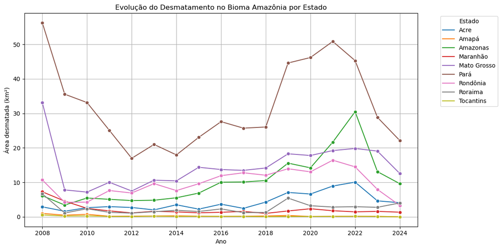

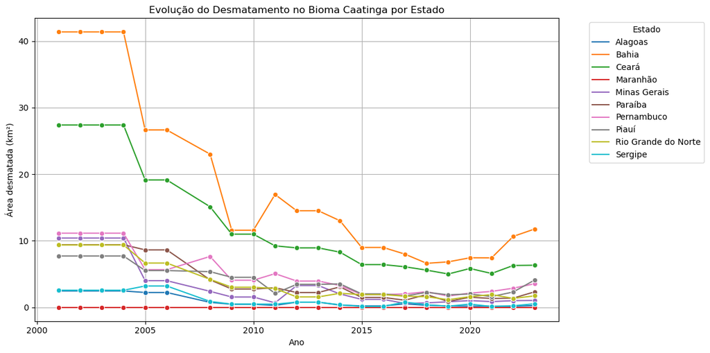

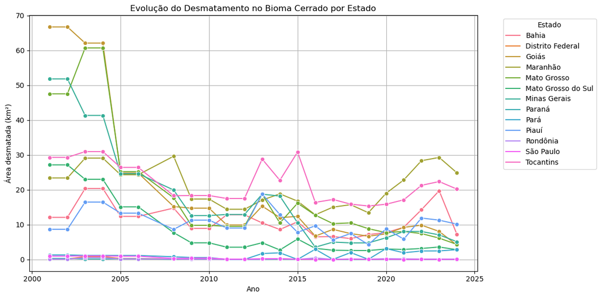

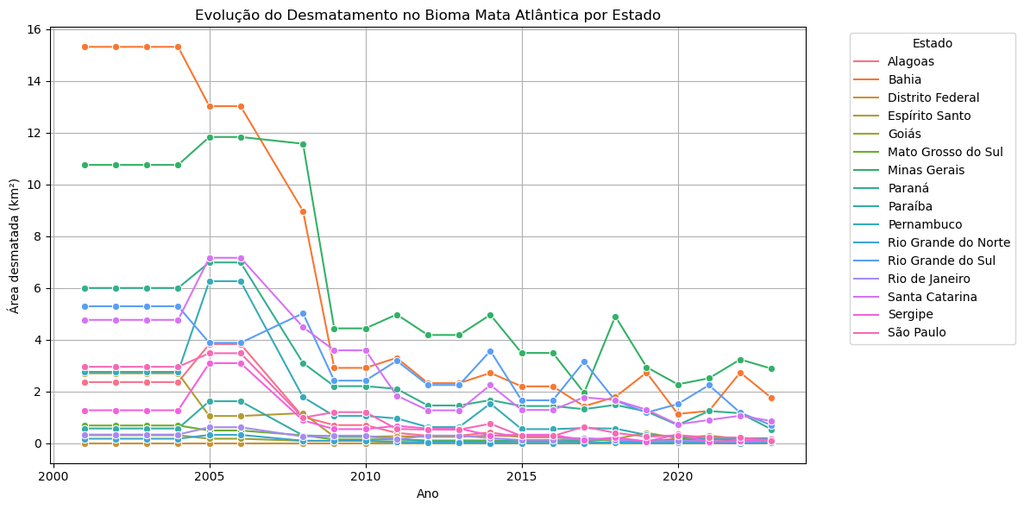

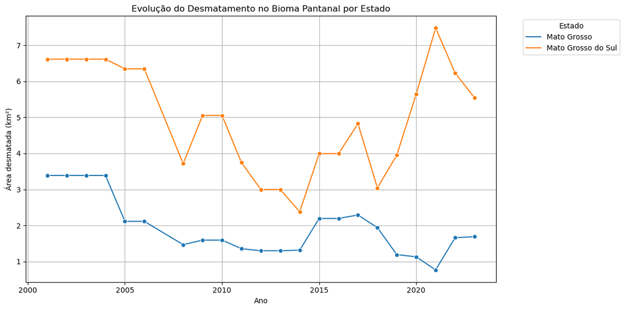

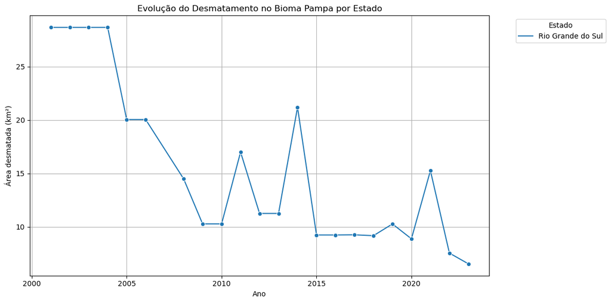

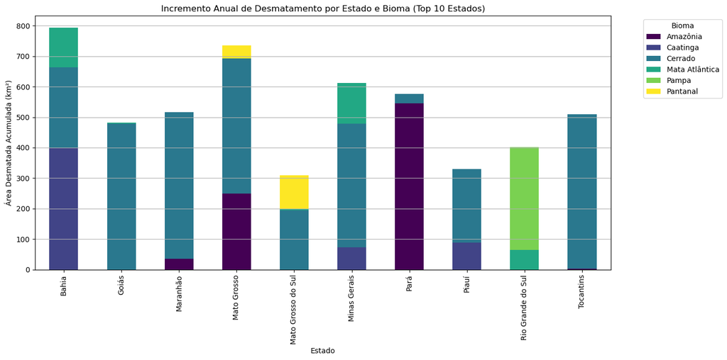

# Dados das Unidades de Conservação

As Unidades de Conservação (UCs) são entidades únicas, sob a gestão de um único órgão e administradas por uma única esfera federativa. No entanto, uma mesma UC pode abranger o território de mais de um município, bem como estar localizada em áreas que pertencem a diferentes biomas.

#### Insconsistencia 1

Dados numéricos como categóricos, como :Área soma biomas, Área soma Biomas Continenta, Área Ato Legal de Criaçoe % Além da linha de costa. t

|  | ID_UC | Área soma biomas | Área soma Biomas Continental | Área Ato Legal de Criação | % Além da linha de costa |
| --- | --- | --- | --- | --- | --- |
| 0 | 1 | 4.437 | 1.877 | 3.000 | 57,7% |
| 1 | 2 | 143.356 | 143.356 | 143.866 | 0,0% |
| 2 | 3 | 41.784 | 41.784 | 41.784 | 0,0% |
| 3 | 4 | 82.681 | 82.681 | 0 | 0,0% |
| 4 | 5 | 150.375 | 150.375 | 150.700 | 0,0% |
| ... | ... | ... | ... | ... | ... |
| 3180 | 4.455 | 116 | 116 | 116 | 0,0% |
| 3181 | 4.678 | 36 | 36 | 36 | 0,0% |
| 3182 | 4.708 | 3.079 | 3.079 | 3.079 | 0,0% |
| 3183 | 4.813 | 30 | 30 | 30 | 0,0% |
| 3184 | 4.609 | 19 | 19 | 16 | 0,0% |

3185 rows × 5 columns

|  | ID_UC | Área soma biomas | Área soma Biomas Continental | Área Ato Legal de Criação | % Além da linha de costa |
| --- | --- | --- | --- | --- | --- |
| 0 | 1 | 4437.0 | 1877 | 3000.0 | 0.577 |
| 1 | 2 | 143356.0 | 143356 | 143866.0 | 0.000 |
| 2 | 3 | 41784.0 | 41784 | 41784.0 | 0.000 |
| 3 | 4 | 82681.0 | 82681 | 0.0 | 0.000 |
| 4 | 5 | 150375.0 | 150375 | 150700.0 | 0.000 |
| ... | ... | ... | ... | ... | ... |
| 3180 | 4.455 | 116.0 | 116 | 116.0 | 0.000 |
| 3181 | 4.678 | 36.0 | 36 | 36.0 | 0.000 |
| 3182 | 4.708 | 3079.0 | 3079 | 3079.0 | 0.000 |
| 3183 | 4.813 | 30.0 | 30 | 30.0 | 0.000 |
| 3184 | 4.609 | 19.0 | 19 | 16.0 | 0.000 |

3185 rows × 5 columns

```
Área soma biomas  tem  17 outliers de  3185 tuplas com valores diferentes de zero
Área soma Biomas Continental  tem  77 outliers de  3169 tuplas com valores diferentes de zero
Área Ato Legal de Criação  tem  15 outliers de  3136 tuplas com valores diferentes de zero
% Além da linha de costa  tem  0 outliers de  216 tuplas com valores diferentes de zero
```

A análise identificou poucos valores discrepantes (outliers) nas variáveis numéricas relacionadas à área, mesmo após excluir os zeros, que representam casos especiais ou ausentes.

```
Bioma de Área soma biomas que são outlier:
 Bioma declarado
Amazônia        12
Área Marinha     5
dtype: int64

Bioma de Área soma biomas Continental que são outlier:
 Bioma declarado
Mata Atlântica    24
Cerrado            3
Amazônia           1
Caatinga           1
Pampa              1
Área Marinha       1
dtype: int64
```

A presença de outliers está associada à natureza dos biomas e à escala das UCs, e não necessariamente indica erro ou anomalia.

#### Insconsistencia 2

Dois atributos como potenciais chaves

```
ID_UC únicos: 3185
Código UC únicos: 3185
```

```
610
```

```
3185
```

**Hipotese:** O ID_UC é parte da chave de Código UC, mas não são ambos chaves. ID_UC é incrementado a cada nova inserção, por isso é cresecente e linear. Já Código UC tem parte dela definida pelo ID_UC mas é apenas um código identificador que não cabe como numérico.

```
Maior ID UC: 5055
```

```
Correlação entre o ID UC e o ano de criação: 0.6931544598902324
Correlação entre o ID UC e o ato legal mais recente: 0.7394185051780178
```

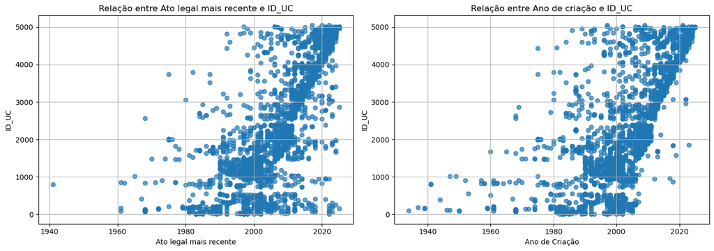

# Análise Exploratória

Após preparação dos dados os dados foram organizados da seguinte maneira:

```
CREATE TABLE gestor (
    codigo_gestor TEXT PRIMARY KEY
);

CREATE TABLE bioma (
    bioma VARCHAR PRIMARY KEY
);

CREATE TABLE esfera_administrativa (
    esfera_administrativa VARCHAR PRIMARY KEY
);

CREATE TABLE uc (
    codigo_uc VARCHAR PRIMARY KEY,
    id_uc INTEGER UNIQUE NOT NULL,
    nome_uc TEXT NOT NULL,
    informacoes_gerais TEXT,
    esfera_administrativa VARCHAR REFERENCES esfera_administrativa(esfera_administrativa),
    categoria_manejo VARCHAR,
    categoria_iucn VARCHAR,
    uf CHAR(2),
    ano_criacao INTEGER,
    ano_ato_legal INTEGER,
    ato_legal_criacao TEXT,
    outros_atos_legais TEXT,
    plano_manejo INTEGER,
    conselho_gestor INTEGER,
    codigo_gestor VARCHAR REFERENCES gestor(codigo_gestor) ON DELETE SET NULL,
    orgao_gestor INTEGER,
    fonte_area INTEGER,
    area_soma_biomas DECIMAL(14,6),
    area_soma_biomas_continental DECIMAL(14,6),
    area_ato_legal DECIMAL(14,6),
    bioma_area DECIMAL(14,6),
    percentual_alem_linha_costa DECIMAL(5,2),
    grupo VARCHAR,
    pi INTEGER,
    us INTEGER,
    recortes_ha DECIMAL(14,6),
    mar_territorial INTEGER,
```

[output cut: 104 more lines]

```
    GROUP BY df.codigo_uc, ma.municipio, ma.uf, mb.bioma, uc.ano_criacao, af.ano_fim_dados
)

SELECT
    uc.nome_uc,
    du.ano_criacao,
    du.ano_fim_dados - du.ano_criacao AS tempo_uc,
    du.municipio,
    du.uf,
    du.bioma,
    du.desmatamento_antes,
    du.desmatamento_depois
FROM desmatamento_uc du
JOIN uc ON du.codigo_uc = uc.codigo_uc
ORDER BY du.municipio, du.uf;
```

```
Atributos nulos na tabela Unidades de Conservação:
                                coluna  nulos
0                               id_uc      0
1                           codigo_uc      0
2            data_certificacao_gestor      0
3                data_publicacao_cnuc      0
4                         codigo_wdpa      0
5   qualidade_dados_georreferenciados      0
6                    reserva_biosfera   1002
7                             mosaico   2969
8                       sitios_ramsar   3112
9           sitios_patrimonio_mundial   3143
10                   programa_projeto   2992
11    municipio_costeiro_area_marinha      0
12                 municipio_costeiro      0
```

[output cut: 63 more lines]

Após a análise exploratória realizada no PostgreSQL com SQL, observou-se que a **tabela de incremento de desmatamento está bem estruturada**, sem a presença de valores nulos. Em contrapartida, a **tabela referente às Unidades de Conservação (UCs) apresentou diversas inconsistências**, incluindo variáveis com altos índices de valores ausentes e áreas registradas com valor zero. Além disso, foram identificados erros de formatação nos dados numéricos, como o uso indevido de ponto para separação de milhar e vírgula como separador decimal. Essas inconsistências foram corrigidas ao longo do processo de desenvolvimento e limpeza do banco de dados.

#### Correlações

|  | codigo_uc | nome_uc | ano_criacao | tempo_uc | municipio | uf | bioma | desmatamento_antes | desmatamento_depois |
| --- | --- | --- | --- | --- | --- | --- | --- | --- | --- |
| 0 | 0000.00.2123 | RESERVA PARTICULAR DO PATRIMÔNIO NATURAL PICO ... | 2010 | 13 | ABAÍRA | BA | Caatinga | 0.133555 | 0.090093 |
| 1 | 0000.00.0261 | ESTAÇÃO ECOLÓGICA DA MATA PRETA | 2005 | 18 | ABELARDO LUZ | SC | Mata Atlântica | 2.080774 | 3.017166 |
| 2 | 0000.26.1928 | ÁREA DE PROTEÇÃO AMBIENTAL ALDEIA-BEBERIBE | 2010 | 13 | ABREU E LIMA | PE | Mata Atlântica | 3.754277 | 0.444442 |
| 3 | 0000.22.4808 | ÁREA DE PROTEÇÃO AMBIENTAL DAS NASCENTES DO RI... | 2017 | 6 | ACAUÃ | PI | Caatinga | 2.032347 | 0.356605 |
| 4 | 0134.52.3062 | ÁREA DE PROTEÇÃO AMBIENTAL DOS BURITIS | 2022 | 2 | ACREÚNA | GO | Cerrado | 1.398343 | 0.010851 |
| ... | ... | ... | ... | ... | ... | ... | ... | ... | ... |
| 3073 | 0000.33.3549 | REFÚGIO DE VIDA SILVESTRE ESTADUAL DO MÉDIO PA... | 2016 | 7 | VOLTA REDONDA | RJ | Mata Atlântica | 0.682050 | 0.120676 |
| 3074 | 6305.33.4672 | PARQUE NATURAL MUNICIPAL VOLTA REDONDA | 2021 | 2 | VOLTA REDONDA | RJ | Mata Atlântica | 0.009141 | 0.000000 |
| 3075 | 6305.33.4957 | REFÚGIO DE VIDA SILVESTRE VALE DOS PURIS | 2019 | 4 | VOLTA REDONDA | RJ | Mata Atlântica | 0.009020 | 0.000121 |
| 3076 | 0000.29.0301 | ÁREA DE PROTEÇÃO AMBIENTAL CAMINHOS ECOLÓGICOS... | 2003 | 20 | WENCESLAU GUIMARÃES | BA | Mata Atlântica | 0.124993 | 2.282827 |
| 3077 | 0000.17.1493 | ÁREA DE PROTEÇÃO AMBIENTAL LAGO DE SANTA ISABEL | 2002 | 22 | XAMBIOÁ | TO | Amazônia | 0.059124 | 33.433080 |

3078 rows × 9 columns

[output not shown]

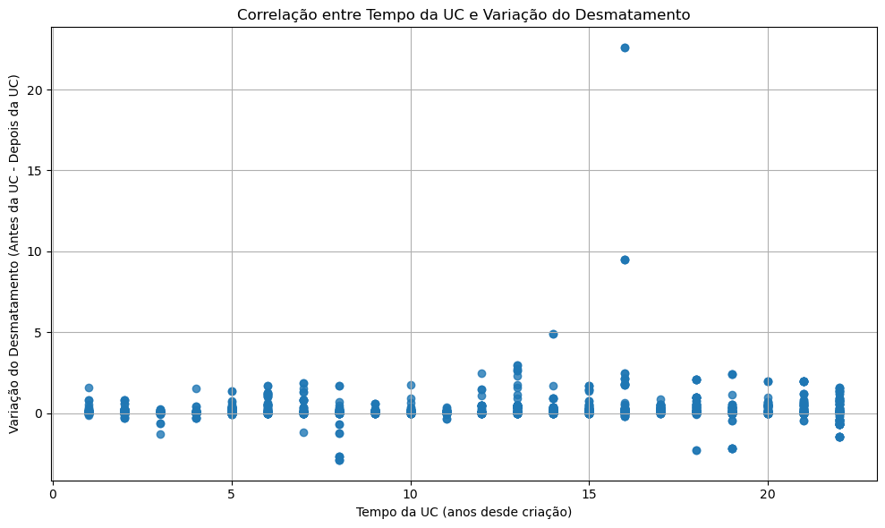

```
Correlação entre tempo da UC e variação do desmatamento: 0.0709
```

# Principais Desafios:

- Dados desorganizados e inconsistentes
- Uso incorreto de pontuação nos arquivos de origem (ex.: vírgula como separador decimal e ponto como separador de milhar)
- Na tabela de Unidades de Conservação, identificaram-se diversas anomalias nos processos de inserção, atualização e remoção de dados, o que resultou em grande quantidade de valores nulos
- Necessidade de adaptação dos arquivos CSV para garantir compatibilidade com o banco de dados
- Grande número de atributos em algumas tabelas, dificultando a modelagem e análise

# Bibliografia e Links Uteis:

- **Fonte dos dados das Unidades de Conservação:**  
  Portal de Dados Abertos MMA *(https://dados.mma.gov.br/dataset/unidadesdeconservacao)*
- **Paindel de Dados das Unidades de Conservação:** *(https://cnuc.mma.gov.br/powerbi)*
- **Fonte dos dados *tabulados* de Incremento de Desmatamento por Bioma:**  
  TerraBrasilis (painel interativo do INPE) *( https://terrabrasilis.dpi.inpe.br/app/dashboard/deforestation/biomes)*
- **Dados *originais* de Incremento na supressão da vegetação nativa por Bioma:**  
  **Fonte:** TerraBrasilis Catalogue
  - **Amazonia:** *[https://terrabrasilis.dpi.inpe.br/geonetwork/srv/eng/catalog.search#/metadata/amazonia](https://terrabrasilis.dpi.inpe.br/geonetwork/srv/eng/catalog.search#/metadata/b75b83db-8026-43f9-9537-ee1dfa308158)*
  - **Amazonia Legal:** *[https://terrabrasilis.dpi.inpe.br/geonetwork/srv/eng/catalog.search#/metadata/amazonialegal](https://terrabrasilis.dpi.inpe.br/geonetwork/srv/eng/catalog.search#/metadata/a5220c18-f7fa-4e3e-b39b-feeb3ccc4830)*
  - **Cerrado:** *[https://terrabrasilis.dpi.inpe.br/geonetwork/srv/eng/catalog.search#/metadata/cerrado](https://terrabrasilis.dpi.inpe.br/geonetwork/srv/eng/catalog.search#/metadata/6b621182-93d6-4a83-b5db-ae53a621276d)*
  - **Caatinga:** *[https://terrabrasilis.dpi.inpe.br/geonetwork/srv/eng/catalog.search#/metadata/caating](https://terrabrasilis.dpi.inpe.br/geonetwork/srv/eng/catalog.search#/metadata/6f585e6e-dae3-4a5b-b74-7c24dedf67ed)*
  - **Mata Atlântica:** *[https://terrabrasilis.dpi.inpe.br/geonetwork/srv/eng/catalog.search#/metadata/mataatlantica](https://terrabrasilis.dpi.inpe.br/geonetwork/srv/eng/catalog.search#/metadata/2b439f5a-b53d-4d56-9937-99026a205e9e)*
  - **Pantanal:** *[https://terrabrasilis.dpi.inpe.br/geonetwork/srv/eng/catalog.search#/metadata/pantanal](https://terrabrasilis.dpi.inpe.br/geonetwork/srv/eng/catalog.search#/metadata/616943ab-a40f-4196-9592-ecc6a7c4901e)*
  - **Pampa:** *[https://terrabrasilis.dpi.inpe.br/geonetwork/srv/eng/catalog.search#/metadata/pampa](https://terrabrasilis.dpi.inpe.br/geonetwork/srv/eng/catalog.search#/metadata/a551570c-78a2-45b3-95e8-0e518fbce941)*